# ChromBPNet predictions and interplay with TF binding

Kaelan (1028-02098-001-001)

August 30, 2022

# 1. Introduction

The goal of this analysis is to plot observed ATAC-seq data and compare it to data predicted by our deep learning model ChromBPNet at enhancers of interst. We will also compare TF binding and chromatin accessibility at our BPNet-mapped motifs to ask about the interplay between binding and accessibility. Note that this analysis generates Figure 2.

# 2. Computational Setup

```r
#Standard packages
library(rtracklayer) ; library(GenomicRanges); library(magrittr) ; library(Biostrings)
library(ggplot2) ; library(reshape2); library(plyranges); library(Rsamtools); library(ggpubr)
library(dplyr); library(data.table); library(patchwork); library(readr); library(testit); library(cowplot)

#KNITR Options
setwd("/l/Zeitlinger/ZeitlingerLab/Manuscripts/Zelda_and_Nucleosomes/Analysis/analysis/")
options(knitr.figure_dir="figures/11_acc_summary_w_binding/", java.parameters = "- Xmx6g")

#Lab sources
source("scripts/r/granges_common.r")
source("scripts/r/metapeak_common.r")
source("scripts/r/knitr_common.r")
source("scripts/r/caching.r")
source("scripts/r/metapeak_functions.r")

#Specific sources
library(ggseqlogo)
library(BSgenome.Dmelanogaster.UCSC.dm6)
library(rhdf5)
source("scripts/r/motif_functions.r")

#Pre-existing variables
modisco_dir <- 'bpnet/modisco/fold1/'
tasks <- c('Zld','Dl','Twi','Bcd','Cad','GAF')
threads <- 5
bsgenome<-BSgenome.Dmelanogaster.UCSC.dm6
```

# 3. Import relevant data for this analysis

```r
obs_atac.bw <- list(orer_1to15 = '/l/Zeitlinger/ZeitlingerLab/Manuscripts/Zelda_and_Nucleosomes/Analysis/data/bw/dm6/atac/combined/orer_1to15_atac_combined_normalized.bw',
                    orer_15to2 = '/l/Zeitlinger/ZeitlingerLab/Manuscripts/Zelda_and_Nucleosomes/Analysis/data/bw/dm6/atac/combined/orer_15to2_atac_combined_normalized.bw',
                    orer_2to25 = '/l/Zeitlinger/ZeitlingerLab/Manuscripts/Zelda_and_Nucleosomes/Analysis/data/bw/dm6/atac/combined/orer_2to25_atac_combined_normalized.bw',
                    orer_25to3 = '/l/Zeitlinger/ZeitlingerLab/Manuscripts/Zelda_and_Nucleosomes/Analysis/data/bw/dm6/atac/combined/orer_25to3_atac_combined_normalized.bw')

atac_peaks.gr <- rtracklayer::import('/l/Zeitlinger/ZeitlingerLab/Manuscripts/Zelda_and_Nucleosomes/Analysis/data/narrowpeak/atac_orer_all_peaks_no_promoters.narrowpeak') %>%
  GenomicRanges::reduce(ignore.strand = T) %>%
  GenomicRanges::resize(1, 'center')

enhancers.gr <- rtracklayer::import("/l/Zeitlinger/ZeitlingerLab/Manuscripts/Zelda_and_Nucleosomes/Analysis/analysis/bed/enhancers/enhancers_for_models.bed")

motifs.gr<-readr::read_tsv('/l/Zeitlinger/ZeitlingerLab/Manuscripts/Zelda_and_Nucleosomes/Analysis/analysis/tsv/mapped_motifs/all_instances_curated_1based.tsv.gz') %>%
  makeGRangesFromDataFrame(keep.extra.columns = T, starts.in.df.are.0based = F) %>%
  plyranges::mutate(motif = pattern_name,
                    name = pattern_name) %>%
  GenomicRanges::sort(ignore.strand = T)

# Note that for for observed and predicted enhancers we will generate these for all time points, separately

t1.bw.list <- list(`Obs. pileup` = '/l/Zeitlinger/ZeitlingerLab/Manuscripts/Zelda_and_Nucleosomes/Analysis/data/bw/dm6/atac/combined/orer_1to15_atac_combined.bw',
              `Obs. cuts` = '/l/Zeitlinger/ZeitlingerLab/Manuscripts/Zelda_and_Nucleosomes/Analysis/data/bw/dm6/atac/combined/orer_1to15_atac_combined_cutsites.bw',
              `Pred. cuts` = '/l/Zeitlinger/ZeitlingerLab/Manuscripts/Zelda_and_Nucleosomes/Analysis/analysis/chrombpnet/preds/preds_fold1_1to15_w_bias.bw',
              `Pred. \nno Tn5\n cuts` = '/l/Zeitlinger/ZeitlingerLab/Manuscripts/Zelda_and_Nucleosomes/Analysis/analysis/chrombpnet/preds/preds_fold1_1to15_wo_bias.bw',
              `Contribution` = '/l/Zeitlinger/ZeitlingerLab/Manuscripts/Zelda_and_Nucleosomes/Analysis/analysis/chrombpnet/preds/preds_fold1_1to15.counts_scores.bw')

t2.bw.list <- list(`Obs. pileup` = '/l/Zeitlinger/ZeitlingerLab/Manuscripts/Zelda_and_Nucleosomes/Analysis/data/bw/dm6/atac/combined/orer_15to2_atac_combined.bw',
              `Obs. cuts` = '/l/Zeitlinger/ZeitlingerLab/Manuscripts/Zelda_and_Nucleosomes/Analysis/data/bw/dm6/atac/combined/orer_15to2_atac_combined_cutsites.bw',
              `Pred. cuts` = '/l/Zeitlinger/ZeitlingerLab/Manuscripts/Zelda_and_Nucleosomes/Analysis/analysis/chrombpnet/preds/preds_fold1_15to2_w_bias.bw',
              `Pred. \nno Tn5\n cuts` = '/l/Zeitlinger/ZeitlingerLab/Manuscripts/Zelda_and_Nucleosomes/Analysis/analysis/chrombpnet/preds/preds_fold1_15to2_wo_bias.bw',
              `Contribution` = '/l/Zeitlinger/ZeitlingerLab/Manuscripts/Zelda_and_Nucleosomes/Analysis/analysis/chrombpnet/preds/preds_fold1_15to2.counts_scores.bw')

t3.bw.list <- list(`Obs. pileup` = '/l/Zeitlinger/ZeitlingerLab/Manuscripts/Zelda_and_Nucleosomes/Analysis/data/bw/dm6/atac/combined/orer_2to25_atac_combined.bw',
              `Obs. cuts` = '/l/Zeitlinger/ZeitlingerLab/Manuscripts/Zelda_and_Nucleosomes/Analysis/data/bw/dm6/atac/combined/orer_2to25_atac_combined_cutsites.bw',
              `Pred. cuts` = '/l/Zeitlinger/ZeitlingerLab/Manuscripts/Zelda_and_Nucleosomes/Analysis/analysis/chrombpnet/preds/preds_fold1_2to25_w_bias.bw',
              `Pred. \nno Tn5\n cuts` = '/l/Zeitlinger/ZeitlingerLab/Manuscripts/Zelda_and_Nucleosomes/Analysis/analysis/chrombpnet/preds/preds_fold1_2to25_wo_bias.bw',
              `Contribution` = '/l/Zeitlinger/ZeitlingerLab/Manuscripts/Zelda_and_Nucleosomes/Analysis/analysis/chrombpnet/preds/preds_fold1_2to25.counts_scores.bw')

t4.bw.list <- list(`Obs. pileup` = '/l/Zeitlinger/ZeitlingerLab/Manuscripts/Zelda_and_Nucleosomes/Analysis/data/bw/dm6/atac/combined/orer_25to3_atac_combined.bw',
              `Obs. cuts` = '/l/Zeitlinger/ZeitlingerLab/Manuscripts/Zelda_and_Nucleosomes/Analysis/data/bw/dm6/atac/combined/orer_25to3_atac_combined_cutsites.bw',
              `Pred. cuts` = '/l/Zeitlinger/ZeitlingerLab/Manuscripts/Zelda_and_Nucleosomes/Analysis/analysis/chrombpnet/preds/preds_fold1_25to3_w_bias.bw',
              `Pred. \nno Tn5\n cuts` = '/l/Zeitlinger/ZeitlingerLab/Manuscripts/Zelda_and_Nucleosomes/Analysis/analysis/chrombpnet/preds/preds_fold1_25to3_wo_bias.bw',
              `Contribution` = '/l/Zeitlinger/ZeitlingerLab/Manuscripts/Zelda_and_Nucleosomes/Analysis/analysis/chrombpnet/preds/preds_fold1_25to3.counts_scores.bw')
```

# 4. Plot observed ATAC average profiles over the time series

Here we are asking “how does chromatin accessibility change over time?,” and our region set is the ChromBPNet input peak set.

## 4.1. Define functions

```r
# Define function for calculating mp

get_multi_bw_standard_metapeak <- function(gr = gr, bw.list = bw.list, upstream = 500, downstream = 500,smooth = NA){
    mclapply(names(bw.list), function(x){
    bw <- bw.list[[x]]
    standard_metapeak(gr,bw, upstream = upstream, downstream = downstream, smooth = smooth, sample_name = x)
    },mc.cores = 10) %>% dplyr::bind_rows()
}

# Define function for plotting

plot_standard_metapeak <- function(metapeak, name = name, xlab = xlab, ylab = ylab, ncol = NA){
    x <- ggplot(metapeak, aes(x=tss_distance, y=reads)) +
         geom_line(position="identity", alpha = 0.2) +
         geom_smooth(method = "loess", span = 0.3, color = "dodgerblue4")+
         ggtitle(name) +
            facet_wrap(~sample_name, scales = "fixed", ncol = ncol) +
            theme(legend.position = "none") +
            theme(panel.grid.major = element_blank(), panel.grid.minor = element_blank(),
            panel.background = element_blank(), axis.line.x = element_line(colour = "black"),
            axis.line.y = element_line(colour = "black")) +
            xlab(xlab) +
            ylab(ylab)
    x
        }
```

## 4.2. Calculate average normalized ATAC-seq

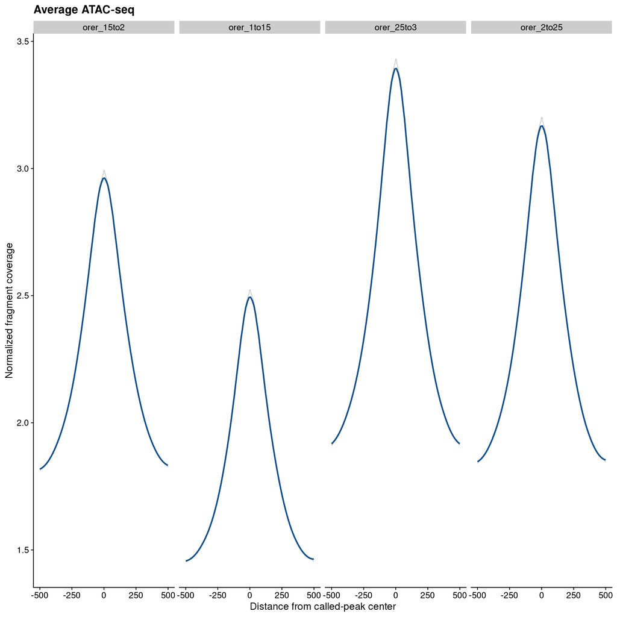

```r
atac_at_peaks.mp <- get_multi_bw_standard_metapeak(gr = atac_peaks.gr, bw.list = obs_atac.bw, upstream = 500, downstream = 500, smooth = 2)
atac_at_peaks.plot <- plot_standard_metapeak(atac_at_peaks.mp, name = "Average ATAC-seq", xlab = "Distance from called-peak center", ylab = "Normalized fragment coverage", ncol = 4) + theme_cowplot()
atac_at_peaks.plot
```

```r
ggsave("atacseq_over_time_average_plots.pdf", plot = atac_at_peaks.plot, path = "figures/11_acc_summary_w_binding", width = 40, height = 20, units = "cm")
ggsave("atacseq_over_time_average_plots.png", plot = atac_at_peaks.plot, path = "figures/11_acc_summary_w_binding", width = 40, height = 20, units = "cm")
```

## 4.3. How does ATAC-seq change over time as a function of the number of Zelda motifs?

```r
# Import islands

islands_with_all_info_filtered.gr <- readRDS("/l/Zeitlinger/ZeitlingerLab/Manuscripts/Zelda_and_Nucleosomes/Analysis/data/islands/zdtbcg_islands_w_all_info.RData")

# separate islands based on how many Zld motifs are in them

zld_counted_islands <- c(islands_with_all_info_filtered.gr[grep(pattern = "Zld-1", x=islands_with_all_info_filtered.gr$island_content),], islands_with_all_info_filtered.gr[grep(pattern = "Zld-2", x=islands_with_all_info_filtered.gr$island_content),], islands_with_all_info_filtered.gr[grep(pattern = "Zld-3", x=islands_with_all_info_filtered.gr$island_content),], islands_with_all_info_filtered.gr[grep(pattern = "Zld-4", x=islands_with_all_info_filtered.gr$island_content),], islands_with_all_info_filtered.gr[grep(pattern = "Zld-5", x=islands_with_all_info_filtered.gr$island_content),])

zld_counted_islands$zld_content <- ifelse(grepl(pattern = "Zld-1", x=zld_counted_islands$island_content), "Zld-1", ifelse(grepl(pattern = "Zld-2", x=zld_counted_islands$island_content), "Zld-2", ifelse(grepl(pattern = "Zld-3", x=zld_counted_islands$island_content), "Zld-3", ifelse(grepl(pattern = "Zld-4", x=zld_counted_islands$island_content), "Zld-4+", ifelse(grepl(pattern = "Zld-5", x=zld_counted_islands$island_content), "Zld-4+", "")))))

# calculate ATAC

atac_across_zld_counted_islands.df <- mclapply(names(obs_atac.bw), function(x){
  regionSums(zld_counted_islands %>% resize(250, 'center'), obs_atac.bw[[x]])
}, mc.cores = 4) %>% as.data.frame()
names(atac_across_zld_counted_islands.df)<-names(obs_atac.bw)

islands_w_atac_zelda.df <- cbind(zld_counted_islands %>% as.data.frame, atac_across_zld_counted_islands.df) %>%
  as.data.table %>% .[,c(12:16)] %>%
  melt.data.table(id.vars = c('zld_content'), variable.name = 'timepoint', value.name = 'ATAC_signal')

# plot

zld_groups <- list(c("Zld-1", "Zld-2"), c("Zld-2", "Zld-3"), c("Zld-3","Zld-4+"), c("Zld-1", "Zld-4+"))

zld_content_islands_plot <- ggplot(islands_w_atac_zelda.df, aes(x=zld_content, y=log2(ATAC_signal))) +
  geom_boxplot(aes(fill = zld_content), outlier.color = NA, outlier.fill = NA) +
  facet_wrap(~timepoint)+
  scale_y_continuous(name = "log2(Normalized ATAC-seq signal)")+
  stat_compare_means(comparisons = zld_groups, method = "wilcox.test", label = "p.signif", paired = FALSE) +
  theme_cowplot()

ggsave("zld_content_increased_plots.pdf", plot = zld_content_islands_plot, path = "figures/11_acc_summary_w_binding", width = 40, height = 20, units = "cm")
ggsave("zld_content_increased_plots.png", plot = zld_content_islands_plot, path = "figures/11_acc_summary_w_binding", width = 40, height = 20, units = "cm")
```

# 5. Plot observed and predicted chromatin accessibility at enhancers

Here we will plot the observed vs. predicted chromatin accessibility at our enhancer list of interest. We will also account for Tn5 bias and show motif contribution.

## 5.1. Define variables and function

```r
#Specific variables

library(RColorBrewer)
n_motifs<-motifs.gr$name %>% unique %>% length
colors <- colorRampPalette(brewer.pal(n_motifs, "Accent"))(n_motifs)
names(colors)<-motifs.gr$name %>% unique
motif.colors.list<-as.list(colors)

# Define function

plot_coverage_and_enhancer<-function(enhancer.gr, motifs.gr, bw.list, motif.colors.list, title, region_width = 1000,
                                     cores = 6, scales = 'fixed', rounding_margin = 50, label_margin = 200){

  #Assertion requirements to make the function run correctly.
  testit::assert("Input enhancer GRanges needs to contain only 1 region.", length(enhancer.gr)==1)
  testit::assert("Motifs need to be a GRanges object", is(motifs.gr, "GRanges"))
  testit::assert("Enhancers need to be a GRanges object", is(enhancer.gr, "GRanges"))
  testit::assert("Region width should be larger than enhancer width.", width(enhancer.gr)<=region_width)
  testit::assert("Bigwig object needs to be a list of samples. If samples are ChIP-nexus/double-stranded samples, they need to be in a nested list.",
                 is(bw.list, "list") & all(!(names(bw.list) %in% c("pos", "neg"))))
  testit::assert("Motif object needs a column titled pattern_name, motif_name, or name to distinguish motifs apart.",
                 any(grepl("pattern_name|name|motif_name", colnames(motifs.gr@elementMetadata))))

  #Find overlaps between motif set and enhancer
  motifs_in_enhancer.gr<-subsetByOverlaps(motifs.gr, resize(enhancer.gr, region_width, "center"), ignore.strand = T)
  if("pattern_name" %in% colnames(motifs_in_enhancer.gr@elementMetadata)){
    motifs_in_enhancer.gr$motif_name<-motifs_in_enhancer.gr$pattern_name
  }
  if("name" %in% colnames(motifs_in_enhancer.gr@elementMetadata)){
    motifs_in_enhancer.gr$motif_name<-motifs_in_enhancer.gr$name
  }

  #Extract colors for enhancer
  fills_in_order<-lapply(motifs_in_enhancer.gr$motif_name, function(x) motif.colors.list[[x]]) %>% unlist %>% unique %>% as.character
  motifs_in_order<-motifs_in_enhancer.gr$motif_name %>% unique %>% as.character
  motifs_in_enhancer.df<-motifs_in_enhancer.gr %>% as.data.frame
  motifs_in_enhancer.df$motif_name<-factor(motifs_in_enhancer.df$motif_name, levels = motifs_in_order)

  #Convert enhancer coordinates to df
  enhancer.df<-enhancer.gr %>% as.data.frame

  #Get half of the enhancer
  enh_half<-floor(width(enhancer.gr)/2)
  lower_bounds<-plyr::round_any(enhancer.df$start - (region_width/2 - enh_half), rounding_margin, f = floor)
  upper_bounds<-plyr::round_any(enhancer.df$end + (region_width/2 - enh_half), rounding_margin, f = ceiling)

  enhancer.plot<-ggplot()+
    geom_hline(yintercept = .5, color = "gray 85")+
    geom_rect(data = enhancer.df, aes(xmin = start, xmax = end, ymin = 0, ymax = 1), fill = "gray 85")+
    geom_text(data = enhancer.df, aes(x = ((start - end)/2 + start), y = .5, label = paste0(seqnames, ":", start, "-", end)),
              color = "black")
  if(nrow(motifs_in_enhancer.df)>0){
    enhancer.plot<-enhancer.plot + geom_rect(data = motifs_in_enhancer.df,
                                             aes(xmin = start, xmax = end, ymin = 1.1, ymax = 2, fill = motif_name), color = 'black', size = .1)
  }
  enhancer.plot<-enhancer.plot+
    scale_fill_manual(values = fills_in_order)+
    scale_x_continuous(breaks = seq(plyr::round_any(enhancer.df$start - (region_width/2 - enh_half), rounding_margin, f = floor),
                                    plyr::round_any(enhancer.df$end + (region_width/2 - enh_half), rounding_margin, f = ceiling), label_margin),
                       limits = c(lower_bounds,upper_bounds))+
    scale_y_continuous(breaks = c(.5, 1.75), labels = c("Enhancer", "Motif(s)"), position = "right")+
    theme_classic()+
    theme(axis.title = element_blank(), axis.line = element_blank(), axis.ticks.y = element_blank(),
          legend.position = "none")

  # Get coverage across bigwig list
  coverage.df<-mclapply(names(bw.list), function(x){
    if(length(bw.list[[x]])==1){
      df<-standard_metapeak(resize(enhancer.gr, 1, "center"), bw.list[[x]], upstream = floor(region_width/2) + rounding_margin, downstream = floor(region_width/2)+300) %>%
        dplyr::rename(window_distance = tss_distance) %>%
        dplyr::mutate(position = window_distance + start(resize(enhancer.gr, 1, "center")), sample_name = x)
    }
    if(length(bw.list[[x]])==2){
      df<-exo_metapeak(resize(enhancer.gr, 1, "center"), bw.list[[x]], upstream = region_width/2 + rounding_margin, downstream = region_width/2+rounding_margin) %>%
        dplyr::rename(window_distance = tss_distance) %>%
        dplyr::mutate(position = window_distance + start(enhancer.gr), sample_name = x)
    }
    return(df)
  }, mc.cores = cores) %>% rbindlist() %>%
    dplyr::filter(position >= lower_bounds, position <= upper_bounds) %>%
    dplyr::mutate(sample_name = factor(sample_name, levels = names(bw.list)))

  #Check for strand if there are no 2-channeled samples.
  if(!("strand" %in% colnames(coverage.df))){
    coverage.df$strand<-NA
  }

  #Plot the enhancer coverage.
  coverage.plot<-ggplot(coverage.df)
  if(nrow(motifs_in_enhancer.df)>0){
    coverage.plot<-coverage.plot + geom_rect(data = motifs_in_enhancer.df, aes(xmin = start, xmax = end, ymin = -Inf, ymax = Inf, fill = motif_name), alpha = .2)
  }
  coverage.plot<-coverage.plot +
    geom_area(aes(x = position, y = reads, group = strand), fill = "black")+
    geom_text(aes(x = Inf, y = Inf, label = sample_name), hjust = -.01)+
    scale_fill_manual(values = fills_in_order)+
    scale_x_continuous(breaks = seq(plyr::round_any(enhancer.df$start - (region_width/2 - enh_half), rounding_margin, f = floor),
                                    plyr::round_any(enhancer.df$end + (region_width/2 - enh_half), rounding_margin, f = ceiling), label_margin),
                       limits = c(lower_bounds,upper_bounds))+
    facet_grid(sample_name ~ ., scales = scales)+
    ggtitle(title)+
    theme_classic()+
    theme(axis.title = element_blank(), axis.line.x = element_blank(), strip.background = element_blank())

  g<-coverage.plot + enhancer.plot + plot_layout(ncol = 1, heights = c(5, 1))
  return(g)
}
```

## 5.2. Plot observed and predicted at enhancers of interest for all timepoints

```r
# 1-1.5 hr AEL

mclapply(1:length(enhancers.gr), function(x){
  enhancer.gr = enhancers.gr[x]
  g<-plot_coverage_and_enhancer(enhancer.gr = enhancer.gr, motifs.gr = motifs.gr, bw.list = t1.bw.list,
                                motif.colors.list = motif.colors.list, title = enhancer.gr$name,
                                region_width = width(enhancer.gr), cores = 6, scales = 'free_y')
  ggsave(paste0("figures/11_acc_summary_w_binding/obs_v_pred/", enhancer.gr$name,"_single_example_atac_1to15.pdf"), g, height = 15, width = 20)
  ggsave(paste0("figures/11_acc_summary_w_binding/obs_v_pred/", enhancer.gr$name,"_single_example_atac_1to15.png"), g, height = 15, width = 20)
  return(g)
}, mc.cores = 4)

# 1.5-2 hr AEL

mclapply(1:length(enhancers.gr), function(x){
  enhancer.gr = enhancers.gr[x]
  g<-plot_coverage_and_enhancer(enhancer.gr = enhancer.gr, motifs.gr = motifs.gr, bw.list = t2.bw.list,
                                motif.colors.list = motif.colors.list, title = enhancer.gr$name,
                                region_width = width(enhancer.gr), cores = 6, scales = 'free_y')
  ggsave(paste0("figures/11_acc_summary_w_binding/obs_v_pred/", enhancer.gr$name,"_single_example_atac_15to2.pdf"), g, height = 15, width = 20)
  ggsave(paste0("figures/11_acc_summary_w_binding/obs_v_pred/", enhancer.gr$name,"_single_example_atac_15to2.png"), g, height = 15, width = 20)
  return(g)
}, mc.cores = 4)

# 2-2.5 hr AEL

mclapply(1:length(enhancers.gr), function(x){
  enhancer.gr = enhancers.gr[x]
  g<-plot_coverage_and_enhancer(enhancer.gr = enhancer.gr, motifs.gr = motifs.gr, bw.list = t3.bw.list,
                                motif.colors.list = motif.colors.list, title = enhancer.gr$name,
                                region_width = width(enhancer.gr), cores = 6, scales = 'free_y')
  ggsave(paste0("figures/11_acc_summary_w_binding/obs_v_pred/", enhancer.gr$name,"_single_example_atac_2to25.pdf"), g, height = 15, width = 20)
  ggsave(paste0("figures/11_acc_summary_w_binding/obs_v_pred/", enhancer.gr$name,"_single_example_atac_2to25.png"), g, height = 15, width = 20)
  return(g)
}, mc.cores = 4)

# 2.5-3 hr AEL

mclapply(1:length(enhancers.gr), function(x){
  enhancer.gr = enhancers.gr[x]
  g<-plot_coverage_and_enhancer(enhancer.gr = enhancer.gr, motifs.gr = motifs.gr, bw.list = t4.bw.list,
                                motif.colors.list = motif.colors.list, title = enhancer.gr$name,
                                region_width = width(enhancer.gr), cores = 6, scales = 'free_y')
  ggsave(paste0("figures/11_acc_summary_w_binding/obs_v_pred/", enhancer.gr$name,"_single_example_atac_25to3.pdf"), g, height = 15, width = 20)
  ggsave(paste0("figures/11_acc_summary_w_binding/obs_v_pred/", enhancer.gr$name,"_single_example_atac_25to3.png"), g, height = 15, width = 20)
  return(g)
}, mc.cores = 4)
```

# 6. Plot ChromBPNet enhancer predictions

Here, we will use ChromBPNet to predict what happens to chromatin accessibility, across time, when we mutate motifs of interest at enhancers. Note that these enhancer predictions were generated first in the following markdown: 7_acc_genomic_perturbs.ipynb

## 6.1. Define variables and functions

```r
# Variables

timepoint.specs.list<-list(`1to15` = '#31218C', `15to2` = '#232996', `2to25` = '#236E96', `25to3` = '#218C89')

myceiling<-function(x, base = 10){
  return( ceiling(x / base) * base)
}
myfloor<-function(x, base = 10){
  return( floor(x / base) * base)
}

enhancer.path <- '/l/Zeitlinger/ZeitlingerLab/Manuscripts/Zelda_and_Nucleosomes/Analysis/analysis/bed/enhancers/enhancers_for_models.bed'

# Function: Given a data.frame with position, prediction, strand, and task columns, plot the profiles across the desired window.

## With no orientation changes
plot_prediction_scores<-function(wt_preds.df, mut_preds.df, motifs_across_window.df,
                                  fill_hex = c('#6e828e', '#7f778c', '#b47382'), color_hex = c('#314d5e', '#493d5c','#94384d')){
  g<-ggplot()

  #Add in motif boxes
  for(row in 1:nrow(motifs_across_window.df)){
    g<-g + annotate("rect", xmin = motifs_across_window.df$start[row], xmax = motifs_across_window.df$end[row],
                    ymin = -Inf, ymax = Inf, alpha = .2)
    g<-g + annotate("text", x = motifs_across_window.df$start[row], label = motifs_across_window.df$pattern_name[row], y = Inf, vjust = 1.5)
  }

  g<-g + geom_area(data = wt_preds.df, mapping = aes(genomic_position_0based, pred, fill = timepoint), alpha = .3)+
    geom_line(data = mut_preds.df, mapping = aes(genomic_position_0based, pred, color = timepoint))+
    facet_grid(timepoint ~ ., scales = "free")+
    scale_x_continuous(name = "Position (bp)")+
    scale_y_continuous(name = "ChromBPNet predictions")+
    scale_fill_manual(values = fill_hex, name = "WT")+
    scale_color_manual(values = color_hex, name = "Variant")+
    theme_classic()
}
```

## 6.2. Format

```r
library(TxDb.Dmelanogaster.UCSC.dm6.ensGene)

enhancers_0based.df<-readr::read_tsv(enhancer.path, col_names = c('chrom','start','end','name','score','strand'))

non_promoter_enhancers.df<-enhancers_0based.df %>% makeGRangesFromDataFrame(keep.extra.columns = T, starts.in.df.are.0based = T) %>%
  .[!overlapsAny(., genes(TxDb.Dmelanogaster.UCSC.dm6.ensGene) %>% resize(., 1, 'start') %>% resize(., 600, 'center'), ignore.strand = T)]
```

## 6.3. Plot

```r
enhancers.vec<-list.files('/l/Zeitlinger/ZeitlingerLab/Manuscripts/Zelda_and_Nucleosomes/Analysis/analysis/tsv/perturbs/accessibility/enhancer/', '_motifs.tsv.gz') %>% gsub('_motifs.tsv.gz','',.) %>% .[. %in% non_promoter_enhancers.df$name]

filler<-mclapply(enhancers.vec, function(x){

  profile_preds.df<-paste0('/l/Zeitlinger/ZeitlingerLab/Manuscripts/Zelda_and_Nucleosomes/Analysis/analysis/tsv/perturbs/accessibility/enhancer/', x, '_preds.tsv.gz') %>% readr::read_tsv()
  profile_preds.df$genomic_position_0based<- profile_preds.df$position + (enhancers_0based.df %>% dplyr::filter(name==x) %>% .$start)
  profile_preds.df$timepoint<-factor(profile_preds.df$timepoint, levels = names(timepoint.specs.list))
  motifs.df<-paste0('/l/Zeitlinger/ZeitlingerLab/Manuscripts/Zelda_and_Nucleosomes/Analysis/analysis/tsv/perturbs/accessibility/enhancer/', x, '_motifs.tsv.gz') %>% readr::read_tsv()

  #Read and filter information
  wt_preds.df<-profile_preds.df %>% dplyr::filter(mut=='Reference')
  mut_preds.df<-profile_preds.df %>% dplyr::filter(mut!='Reference')

  #Coordinate x-axis for predictions and contribution
  # xlim_genomic<-c(min(myfloor(motifs.df$start, 50)-50), max(myceiling(motifs.df$end, 50)+50))
  # xlim_window<-xlim_genomic-motifs.df$enhancer_start_0based[1]
  # motifs.df$contrib_start<-motifs.df$pattern_start - xlim_window[1]
  # motifs.df$contrib_end<-motifs.df$pattern_end - xlim_window[1]

  #Plot predictions as compared to WT (genomic coordinates)
  preds.plot.list<-lapply(unique(mut_preds.df$mut), function(x){
    g<-plot_prediction_scores(wt_preds.df = wt_preds.df, mut_preds.df = mut_preds.df %>% dplyr::filter(mut == x),
                              motifs_across_window.df = motifs.df,
                              fill_hex = timepoint.specs.list %>% unlist, color_hex = timepoint.specs.list %>% unlist)
    g<-g+ggtitle(x) + theme(legend.position = 'none')
    return(g)
  })

  #Create metaplot of the highest and lowest scores
  g<-wrap_plots(preds.plot.list) + plot_layout(ncol = length(preds.plot.list)) + plot_annotation(title = paste0("Enhancer: ", x))
  ggsave(paste0("figures/11_acc_summary_w_binding/perturbs/enh_", x, "_perturbs.pdf"),
         g, height = 8, width = nrow(motifs.df)*4)
  ggsave(paste0("figures/11_acc_summary_w_binding/perturbs/enh_", x, "_perturbs.png"),
         g, height = 8, width = nrow(motifs.df)*4)
  return(NULL)
}, mc.cores = 8)
```

# 7. Plot summarized chromatin accessibility from ChromBPNet

Here we will plot summaries for accessibility counts contribution from our BPNet-discovered and mapped motifs that have been overlapped with accessible regions. We will first collect binding and accessibility contribution at these overlapped motifs.

## 7.1. Normalize contribution tracks

```r
# Variables

timepoints <- c('1to15','15to2','2to25','25to3')
weight_threshold<-'99.95%'
```

```r
# Normalize and export

mclapply(timepoints, function(x){
  contrib_path<-paste0('/l/Zeitlinger/ZeitlingerLab/Manuscripts/Zelda_and_Nucleosomes/Analysis/analysis/chrombpnet/preds/preds_fold1_', x, '.counts_scores.bw')
  contrib.gr<-rtracklayer::import(contrib_path)
  weight_path <- paste0('/l/Zeitlinger/ZeitlingerLab/Manuscripts/Zelda_and_Nucleosomes/Analysis/analysis/chrombpnet/preds/preds_fold1_', x, '.counts_scores.txt')
  weight.df<-read.table(weight_path)
  weight<-weight.df$V2[weight.df$V1==weight_threshold]
  contrib.gr$score<-contrib.gr$score / weight
  rtracklayer::export(contrib.gr, paste0('/l/Zeitlinger/ZeitlingerLab/Manuscripts/Zelda_and_Nucleosomes/Analysis/analysis/chrombpnet/preds/preds_fold1_', x,
                                         '.counts_scores_norm_',
                                         gsub('[\\%,]', '', weight_threshold),'.bw'))
}, mc.cores = 4)
```

## 7.2. Import data necessary for contribution calculation

```r
# motifs that have been overlapped with ATAC regions (from 4_binding_motif_curation)

motifs_ov.gr <- readr::read_tsv('/l/Zeitlinger/ZeitlingerLab/Manuscripts/Zelda_and_Nucleosomes/Analysis/analysis/tsv/mapped_motifs/atac_overlapping_instances_curated_1based.tsv.gz') %>% makeGRangesFromDataFrame(starts.in.df.are.0based = F, keep.extra.columns = T)
motifs_ov.gr$pattern_name %>% table()
```

```
## .
##  Bcd  Cad   Dl  GAF  Twi  Zld
## 5805 5016  800 2556 8771 2608
```

```r
# ATAC contrib normalized bws

contrib.bws<-list.files('/l/Zeitlinger/ZeitlingerLab/Manuscripts/Zelda_and_Nucleosomes/Analysis/analysis/chrombpnet/preds/',
                        pattern = 'counts_scores_norm_99.95', full.names = T, recursive = T) %>% as('list')
names(contrib.bws)<-stringr::str_match(contrib.bws, "preds_fold1_\\s*(.*?)\\s*.counts_scores")[,2]

# TF binding contrib bws (both counts and profile)

tf.bws<-list.files('/l/Zeitlinger/ZeitlingerLab/Manuscripts/Zelda_and_Nucleosomes/Analysis/analysis/bpnet/preds/fold1/bw',
                        pattern = 'contrib', full.names = T, recursive = F) %>% as('list')
names(tf.bws) <- c("Bcd.contrib.counts", "Bcd.contrib.profile", "Cad.contrib.counts", "Cad.contrib.profile", "Dl.contrib.counts", "Dl.contrib.profile", "GAF.contrib.counts", "GAF.contrib.profile", "Twi.contrib.counts", "Twi.contrib.profile", "Zld.contrib.counts","Zld.contrib.profile")
```

## 7.3. Calculate ATAC and ChIP contribution

```r
contrib.df<-lapply(names(contrib.bws), function(x){
  regionSums(motifs_ov.gr, contrib.bws[[x]])
}) %>% as.data.frame()
colnames(contrib.df)<-names(contrib.bws)

tf.df<-mclapply(names(tf.bws), function(x){
  regionSums(motifs_ov.gr, tf.bws[[x]])
}, mc.cores = 8) %>% as.data.frame()
colnames(tf.df)<-names(tf.bws)
```

## 7.4. Merge contribution scores with motif list

```r
motifs_ov.df<-motifs_ov.gr %>%
  plyranges::mutate(seq = getSeq(bsgenome, resize(., width = 30, fix = 'center'))) %>%
  as.data.frame(.) %>%
  cbind(., contrib.df) %>%
  cbind(., tf.df)

motifs_ov.df$`tf.contrib.profile`<-mclapply(1:nrow(motifs_ov.df), function(x){
  motifs_ov.df[[paste0(motifs_ov.df$pattern_name[x], '.contrib.profile')]][x]
}, mc.cores = 8) %>% unlist
motifs_ov.df$`tf.contrib.counts`<-mclapply(1:nrow(motifs_ov.df), function(x){
  motifs_ov.df[[paste0(motifs_ov.df$pattern_name[x], '.contrib.counts')]][x]
}, mc.cores = 8) %>% unlist
motifs_ov.df<-motifs_ov.df %>% as.data.frame
```

## 7.5. Save motifs with metadata

```r
readr::write_tsv(motifs_ov.df, '/l/Zeitlinger/ZeitlingerLab/Manuscripts/Zelda_and_Nucleosomes/Analysis/analysis/tsv/mapped_motifs/atac_overlapping_instances_curated_w_metadata_1based.tsv.gz')
```

## 7.6. Summarize ChromBPNet contribution from BPNet-mapped motifs overlapped with accessible regions

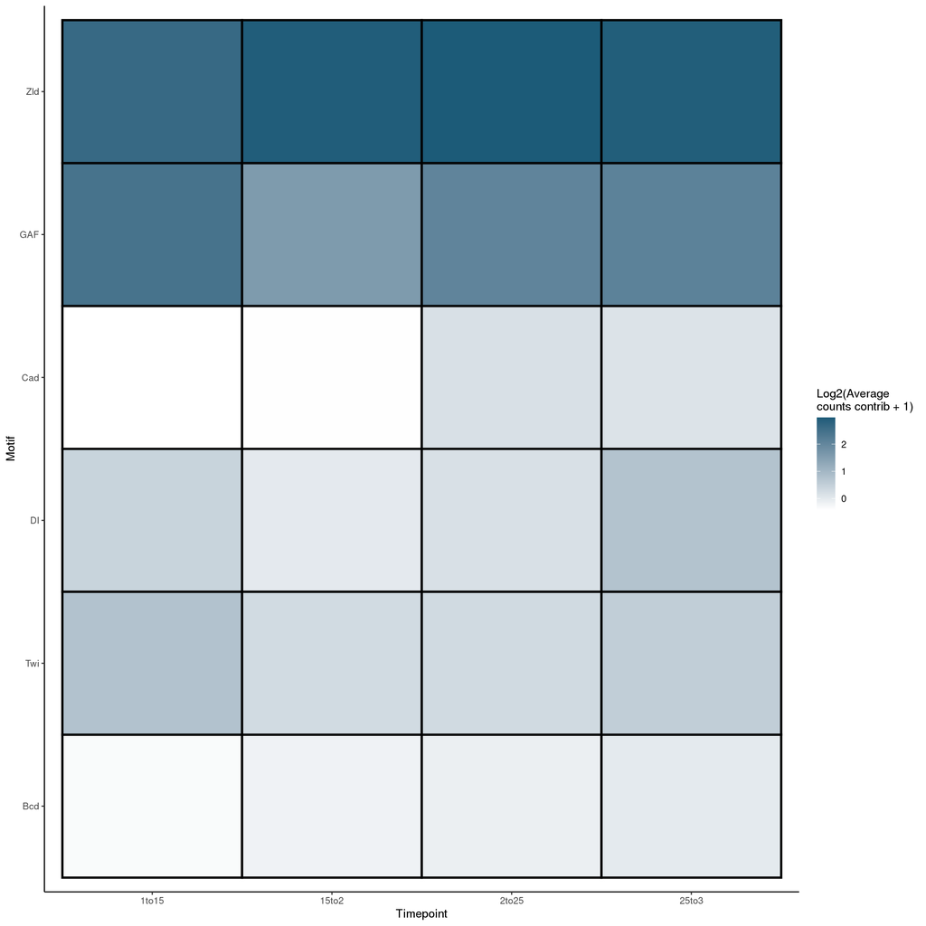

```r
# Variables

motifs_of_interest<-c('Zld', 'GAF', 'Cad', 'Dl','Twi','Bcd')

# Calculate average counts contribution to accessibility

motif_summary.df<-motifs_ov.df %>%
  as.data.table %>%
  melt.data.table(id.vars = c('pattern_name'), measure.vars = timepoints,
                  variable.name = 'timepoint', value.name = 'atac_contrib') %>%
  dplyr::mutate(log_atac_contrib = log2(atac_contrib+1)) %>%
  dplyr::filter(!is.na(log_atac_contrib)) %>%
  dplyr::group_by(pattern_name, timepoint) %>%
  dplyr::summarize(mean_log_atac_contrib = mean(log_atac_contrib),
                   mean_atac_contrib = mean(atac_contrib)) %>%
  dplyr::mutate(pattern_name = factor(pattern_name, levels = rev(motifs_of_interest)),
                timepoint = factor(timepoint, levels = timepoints))

# Plot

colors_raw<-viridis(100, begin = 0, end = 1)
colors_formatted<-colors_raw#c(colors_raw[seq(1, 50, 5)], colors_raw[seq(70, 80, 1)], colors_raw[seq(95, 100, 1)])

motif_summary.plot<-ggplot(motif_summary.df, aes(x = timepoint, y = pattern_name, fill = mean_log_atac_contrib))+
  geom_tile(color = 'black', size = 1)+
  scale_x_discrete(name = 'Timepoint')+
  scale_y_discrete(name = 'Motif')+
  scale_fill_gradient(low = 'white', high = '#1c5b78', name = 'Log2(Average\ncounts contrib + 1)')+
  theme_classic()

motif_summary.plot
```

```r
ggsave("acc_counts_contrib_at_ov_motifs.pdf", plot = motif_summary.plot, path = "figures/11_acc_summary_w_binding", height = 4, width = 4)
ggsave("acc_counts_contrib_at_ov_motifs.png", plot = motif_summary.plot, path = "figures/11_acc_summary_w_binding", height = 4, width = 4)
```

## 7.7 Plot the closest ChromBPNet CWM motif logos for each TF

```r
# Define variables

atac_seqlets.list<-list('Zld' = list(timepoint = '25to3', metacluster = 0, pattern = 0, revcomp = T),
                       'GAF'= list(timepoint = '25to3', metacluster = 0, pattern = 1, revcomp = F),
                       'Cad'= list(timepoint = '2to25', metacluster = 0, pattern =  17, revcomp = T),
                       'Dl'= list(timepoint = '25to3', metacluster = 0, pattern = 9, revcomp = T),
                       'Twi'= list(timepoint = '25to3', metacluster = 0, pattern = 10, revcomp = F))

# Collect information

cwm.list<-mclapply(names(atac_seqlets.list), function(x){
  ##Collect motifs and sequences
  gr<-rtracklayer::import(paste0('/l/Zeitlinger/ZeitlingerLab/Manuscripts/Zelda_and_Nucleosomes/Analysis/analysis/chrombpnet/modisco/fold1_',
                                 atac_seqlets.list[[x]]$timepoint,
                                 '_counts/metacluster_',
                                 atac_seqlets.list[[x]]$metacluster,
                                 '_pattern_',
                                 atac_seqlets.list[[x]]$pattern,
                                 '_seqlets.bed'))
  if(atac_seqlets.list[[x]]$revcomp){
    gr<-gr %>% plyranges::mutate(strand = ifelse(strand=='+', '-', '+'))
  }
  gr<-gr %>% plyranges::mutate(seq = getSeq(bsgenome, ., as.character = T))
  seqs<-gr$seq
  seqs_1he.list<-mclapply(seqs, function(x) one_hot_encode_DNA(x), mc.cores = 8)


  ##Define ATAC-seq contribution
  atac_shap.path<-paste0('/l/Zeitlinger/ZeitlingerLab/Manuscripts/Zelda_and_Nucleosomes/Analysis/analysis/chrombpnet/preds/preds_fold1_',
                         atac_seqlets.list[[x]]$timepoint, '.counts_scores.bw')

  ##Collect contribution
  contrib.mat<-standard_metapeak_matrix(gr, atac_shap.path, keep_region_coordinates = T)
  testit::assert('Arrays do not match.', dim(contrib.mat)[1]==length(seqs_1he.list))

  ##Compute CWM
  cwm.list<-mclapply(1:length(seqs_1he.list), function(z){
    s<-seqs_1he.list[[z]]
    c<-contrib.mat[z,]
    cwm<-lapply(1:length(c), function(y){
      s[,y]*c[y]
    }) %>% as.data.frame
    colnames(cwm)<-NULL
    cwm<-as.matrix(cwm)
    return(cwm)
  }, mc.cores = 8)

  cwm<-Reduce("+", cwm.list) / length(cwm.list)
  return(cwm)
}, mc.cores = 6)

names(cwm.list)<-names(atac_seqlets.list)

# Plot

cwm.plot<-ggplot() + geom_logo(cwm.list, method='custom', seq_type='dna') +
  facet_grid(seq_group~., scales = 'free_y')+
  theme_classic()+
  ggtitle('CWM')+
  theme(axis.line.x = element_blank(), axis.text.x = element_blank(), axis.ticks.x = element_blank(), axis.title = element_blank(),
        strip.background = element_blank())

ggsave("chrombpnet_closest_cwm.pdf", plot = cwm.plot, path = "figures/11_acc_summary_w_binding", height = 8, width = 4)
ggsave("chrombpnet_closest_cwm.png", plot = cwm.plot, path = "figures/11_acc_summary_w_binding", height = 8, width = 4)
```

## 7.8. Plot binding at ChromBPNet closest seqlets

```r
# Import nexus binding information

binding.bw.list <- list(zld_binding = list(pos = "/l/Zeitlinger/ZeitlingerLab/Manuscripts/Zelda_and_Nucleosomes/Analysis/data/bw/dm6/nexus/combined/orer_zld_mbt_nexus_combined_positive.bw",
                                           neg = "/l/Zeitlinger/ZeitlingerLab/Manuscripts/Zelda_and_Nucleosomes/Analysis/data/bw/dm6/nexus/combined/orer_zld_mbt_nexus_combined_negative.bw"),
                        gaf_binding = list(pos = "/l/Zeitlinger/ZeitlingerLab/Manuscripts/Zelda_and_Nucleosomes/Analysis/data/bw/dm6/nexus/combined/orer_gaf_mbt_nexus_combined_positive.bw",
                                           neg = "/l/Zeitlinger/ZeitlingerLab/Manuscripts/Zelda_and_Nucleosomes/Analysis/data/bw/dm6/nexus/combined/orer_gaf_mbt_nexus_combined_negative.bw"),
                        cad_binding = list(pos = "/l/Zeitlinger/ZeitlingerLab/Manuscripts/Zelda_and_Nucleosomes/Analysis/data/bw/dm6/nexus/combined/orer_cad_mbt_nexus_combined_positive.bw",
                                           neg = "/l/Zeitlinger/ZeitlingerLab/Manuscripts/Zelda_and_Nucleosomes/Analysis/data/bw/dm6/nexus/combined/orer_cad_mbt_nexus_combined_negative.bw"),
                        dl_binding = list(pos = "/l/Zeitlinger/ZeitlingerLab/Manuscripts/Zelda_and_Nucleosomes/Analysis/data/bw/dm6/nexus/combined/orer_dl_mbt_nexus_combined_positive.bw",
                                          neg = "/l/Zeitlinger/ZeitlingerLab/Manuscripts/Zelda_and_Nucleosomes/Analysis/data/bw/dm6/nexus/combined/orer_dl_mbt_nexus_combined_negative.bw"),
                        twi_binding = list(pos = "/l/Zeitlinger/ZeitlingerLab/Manuscripts/Zelda_and_Nucleosomes/Analysis/data/bw/dm6/nexus/combined/orer_twi_mbt_nexus_combined_positive.bw",
                                           neg = "/l/Zeitlinger/ZeitlingerLab/Manuscripts/Zelda_and_Nucleosomes/Analysis/data/bw/dm6/nexus/combined/orer_twi_mbt_nexus_combined_negative.bw"))

# get seqlets as a GRanges list onject

motif_seqlets.list<-mclapply(names(atac_seqlets.list), function(x){
  #Collect motifs and sequences
  gr<-rtracklayer::import(paste0('/l/Zeitlinger/ZeitlingerLab/Manuscripts/Zelda_and_Nucleosomes/Analysis/analysis/chrombpnet/modisco/fold1_',
                                 atac_seqlets.list[[x]]$timepoint,
                                 '_counts/metacluster_',
                                 atac_seqlets.list[[x]]$metacluster,
                                 '_pattern_',
                                 atac_seqlets.list[[x]]$pattern,
                                 '_seqlets.bed'))
})
names(motif_seqlets.list) <- c("Zld_motif", "Gaf_motif", "Cad_motif", "Dl_motif", "Twi_motif")

# Calculate each TF individually and plot

zld.binding <- exo_metapeak(gr = resize(motif_seqlets.list$Zld_motif, 1, 'center'), sample = binding.bw.list$zld_binding, upstream = 500, downstream = 500)
zld.seqlets.plot <- ggplot(zld.binding, aes(x=tss_distance, y=reads, fill=strand))+
  geom_area(aes(group=strand))+
  scale_fill_manual(values= alpha(c("red", "dodgerblue4"), 0.4)) +
  ylim(-5,5) +
  xlab("Distance from seqlet center")+
  ylab("Zld ChIP-nexus Reads")+
  ggtitle("Zelda binding at ChromBPNet seqlets")+
  theme_cowplot()

gaf.binding <- exo_metapeak(gr = resize(motif_seqlets.list$Gaf_motif, 1, 'center'), sample = binding.bw.list$gaf_binding, upstream = 500, downstream = 500)
gaf.seqlets.plot <- ggplot(gaf.binding, aes(x=tss_distance, y=reads, fill=strand))+
  geom_area(aes(group=strand))+
  scale_fill_manual(values= alpha(c("red", "dodgerblue4"), 0.4)) +
  ylim(-15,15) +
  xlab("Distance from seqlet center")+
  ylab("GAF ChIP-nexus Reads")+
  ggtitle("GAF binding at ChromBPNet seqlets")+
  theme_cowplot()

cad.binding <- exo_metapeak(gr = resize(motif_seqlets.list$Cad_motif, 1, 'center'), sample = binding.bw.list$cad_binding, upstream = 500, downstream = 500)
cad.seqlets.plot <- ggplot(cad.binding, aes(x=tss_distance, y=reads, fill=strand))+
  geom_area(aes(group=strand))+
  scale_fill_manual(values= alpha(c("red", "dodgerblue4"), 0.4)) +
  ylim(-15,15) +
  xlab("Distance from seqlet center")+
  ylab("Cad ChIP-nexus Reads")+
  ggtitle("Caudal binding at ChromBPNet seqlets")+
  theme_cowplot()

dl.binding <- exo_metapeak(gr = resize(motif_seqlets.list$Dl_motif, 1, 'center'), sample = binding.bw.list$dl_binding, upstream = 500, downstream = 500)
dl.seqlets.plot <- ggplot(dl.binding, aes(x=tss_distance, y=reads, fill=strand))+
  geom_area(aes(group=strand))+
  scale_fill_manual(values= alpha(c("red", "dodgerblue4"), 0.4)) +
  ylim(-15,15) +
  xlab("Distance from seqlet center")+
  ylab("Dl ChIP-nexus Reads")+
  ggtitle("Dorsal binding at ChromBPNet seqlets")+
  theme_cowplot()

twi.binding <- exo_metapeak(gr = resize(motif_seqlets.list$Twi_motif, 1, 'center'), sample = binding.bw.list$twi_binding, upstream = 500, downstream = 500)
twi.seqlets.plot <- ggplot(twi.binding, aes(x=tss_distance, y=reads, fill=strand))+
  geom_area(aes(group=strand))+
  scale_fill_manual(values= alpha(c("red", "dodgerblue4"), 0.4)) +
  ylim(-5,5) +
  xlab("Distance from seqlet center")+
  ylab("Twi ChIP-nexus Reads")+
  ggtitle("Twist binding at ChromBPNet seqlets")+
  theme_cowplot()

tfs_at_seqlets.plot <- zld.seqlets.plot + gaf.seqlets.plot + cad.seqlets.plot + dl.seqlets.plot + twi.seqlets.plot

ggsave("tfs_binding_at_seqlets.pdf", plot = tfs_at_seqlets.plot, path = "figures/11_acc_summary_w_binding", height = 8, width = 24)
ggsave("tfs_binding_at_seqlets.png", plot = tfs_at_seqlets.plot, path = "figures/11_acc_summary_w_binding", height = 8, width = 24)
```

# 8. Plot binding contirbution vs. accessibility contribution across motifs

Here we will correlate the binding and accessibility contribution accross all motifs of interest

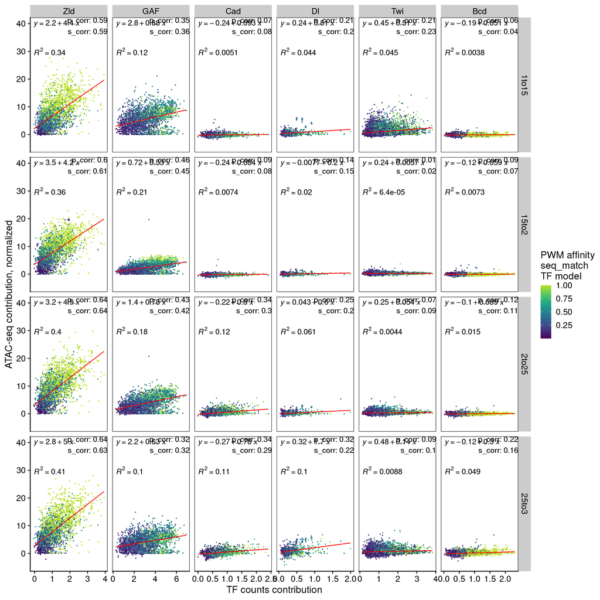

```r
# Gather contribution scores and compare to motif affinity
contrib_comparison.df<-motifs_ov.df %>%
  as.data.table %>%
  melt.data.table(id.vars = c('tf.contrib.counts', 'pattern_name', 'seq_match_p'), measure.vars = timepoints,
                  value.name = 'atac_contrib', variable.name = 'timepoint') %>%
  dplyr::mutate(timepoint = factor(timepoint, levels = timepoints))

# Calculate correlation values
contrib_corrs.df<-contrib_comparison.df %>%
  dplyr::group_by(pattern_name, timepoint) %>%
  dplyr::summarize(p_corr = round(cor(`tf.contrib.counts`, atac_contrib, method = 'pearson'), 2),
                   s_corr = round(cor(`tf.contrib.counts`, atac_contrib, method = 'spearman'), 2)) %>%
  dplyr::mutate(timepoint = factor(timepoint, levels = timepoints))

#Plot values

contrib_comparison.df$pattern_name<-contrib_comparison.df$pattern_name %>% factor(., levels = motifs_of_interest)
contrib_corrs.df$pattern_name<-contrib_corrs.df$pattern_name %>% factor(., levels = motifs_of_interest)

tf_vs_atac_contrib.plot<-ggplot(contrib_comparison.df, aes(x = `tf.contrib.counts`, y = atac_contrib)) +
  geom_point(aes(color = seq_match_p), size = .2) +
  geom_smooth(method=lm, se=FALSE, col='red', size=0.5) +
  geom_text(data = contrib_corrs.df, aes(x = Inf, y = Inf, label = paste0('p_corr: ', p_corr, '\n', 's_corr: ', s_corr)),vjust = 1, hjust = 1) +
  stat_regline_equation(label.y = 30, aes(label = ..rr.label..)) +
  stat_regline_equation(label.y = 40, aes(label = ..eq.label..)) +
  scale_y_continuous('ATAC-seq contribution, normalized')+
  scale_x_continuous('TF counts contribution')+
  scale_color_gradientn(colors = viridis(50, end = .9), name = 'PWM affinity\nseq_match\nTF model')+
  facet_grid(timepoint~pattern_name, scales = "free_x")+
  theme_cowplot()+
  theme(panel.background = element_rect(color = 'black'))
tf_vs_atac_contrib.plot
```

```r
ggsave("tf_counts_contrib_vs_atac_contrib.pdf", plot = tf_vs_atac_contrib.plot, path = "figures/11_acc_summary_w_binding", width = 12, height = 8)
ggsave("tf_counts_contrib_vs_atac_contrib.png", plot = tf_vs_atac_contrib.plot, path = "figures/11_acc_summary_w_binding", width = 12, height = 8)
```

# 9. Plot Tn5 bias logos

```r
tn5_p1 <- read.delim(file = '/l/Zeitlinger/ZeitlingerLab/Manuscripts/Zelda_and_Nucleosomes/Analysis/analysis/chrombpnet/modisco/thresh_5_profile/metacluster_0_pattern_0_seqlets.txt')
tn5_p1_odd <- seq_len(nrow(tn5_p1)) %% 2
tn5_p1 <- tn5_p1[tn5_p1_odd== 1, ]

tn5_p2 <- read.delim(file = '/l/Zeitlinger/ZeitlingerLab/Manuscripts/Zelda_and_Nucleosomes/Analysis/analysis/chrombpnet/modisco/thresh_5_profile/metacluster_0_pattern_1_seqlets.txt')
tn5_p2_odd <- seq_len(nrow(tn5_p2)) %% 2
tn5_p2 <- tn5_p2[tn5_p2_odd== 1, ]

tn5_p3 <- read.delim(file = '/l/Zeitlinger/ZeitlingerLab/Manuscripts/Zelda_and_Nucleosomes/Analysis/analysis/chrombpnet/modisco/thresh_5_profile/metacluster_0_pattern_2_seqlets.txt')
tn5_p3_odd <- seq_len(nrow(tn5_p3)) %% 2
tn5_p3 <- tn5_p3[tn5_p3_odd== 1, ]

tn5_logo1 <- ggplot() + geom_logo(tn5_p1) + theme_logo() + ggtitle("Tn5 bias logo 1")
tn5_logo2 <- ggplot() + geom_logo(tn5_p2) + theme_logo() + ggtitle("Tn5 bias logo 2")
tn5_logo3 <- ggplot() + geom_logo(tn5_p3) + theme_logo() + ggtitle("Tn5 bias logo 3")

tn5.bias.logos <- tn5_logo1 + tn5_logo2 + tn5_logo3

ggsave("tn5_bias_logos.pdf", plot = tn5.bias.logos, path = "figures/11_acc_summary_w_binding", width = 12, height = 8)
ggsave("tn5_bias_logos.png", plot = tn5.bias.logos, path = "figures/11_acc_summary_w_binding", width = 12, height = 8)
```

# 10. Conclusions

Here, we have processed the BPNet-mapped motifs that overlap with acessible regions, and we have shown the correlation between accessibility and binding contribution for all of the TFs of interest at these motifs, across time. We see a striking pattern for the known pioneers Zelda and GAF. We see this further reflected in the strong contribution of these motifs to accessibility when we summarize the contribution. Finally, we have used our known enhancers and plotted both the observed and predicted coverage as well as ChromBPNet predictions upon motif mutation, which shows how individual TFs/motifs are predicted to influence chromatin accessibility across time.